# MAESTRÍA EN ESTADÍSTICA

ANÁLISIS MULTIVARIADO

Kevin Heberth Haquehua Apaza

02 de agosto del 2025

[figure not shown]

# Sección 1. Contexto y objetivo del estudio. Datos.

## Exploración de datasets

La importación de un conjunto de datos externo, en concreto uno contenido en el repositorio publico de [**Kaggle**](https://www.kaggle.com/datasets).  
Esto nos va a permitir, entre otras cosas, practicar con otras técnicas de carga de datos, más allá de la utilización de datasets contenidos en paquetes predefinidos en R.

## Elección y Descripción del dataset

En concreto, el dataset utilizado es [**CpG Values of Smoking and Non Smoking Patients**](https://www.kaggle.com/datasets/thomaskonstantin/cpg-values-of-smoking-and-non-smoking-patients), creado por [*Thomas Konstantin*](https://www.kaggle.com/thomaskonstantin), investigador en la *Universidad de Bar-Ilan de Tel Aviv*.

### Contexto biológico

En la página del dataset se proporciona un breve contexto acerca del contenido del mismo y el origen biológico de la información. En concreto, el dataset contiene información sobre los **niveles de metilación** en 20 **CG islands** para **671 muestras** únicas, junto con la *edad*, *género* y *código* de la muestra. En relación a las **CG islands**, o *islas CpG*, el autor ofrece una breve explicación que tratamos de sintetizar.  
En el ADN se pueden localizar lo que se denominan *sitios CpG*, o *CpG sites*, que no son otra cosa que *di-nucleótidos* en los que una *citosina* es seguida por una *guanina*. Y a su vez, las *islas CpG* son regiones en las que hay una alta concentración de *sitios CpG*.  
Estos *dinucleótidos* pueden aparecer *metilados*, lo que significa que la *citosina* correspondiente recibe un grupo metilo (-CH3) para acabar formando una *5-metilcitosina*. Esto es importante porque las metilaciones que ocurren en un gen pueden influir en su expresión.  
El estudio de las metilaciones, y su influencia en la expresión genética, forma parte de un campo aún mayor que se denomina *epigenética*. El autor del dataset menciona que podría ser interesante estudiar la relación entre los datos que se proporcionan de los pacientes (género, edad y condición de fumador o no fumador), y los niveles de metilación en las diferentes *CpG islands*.  
Este tipo de relaciones son precisamente las que la técnicas de análisis multivariado pueden ayudar a desentrañar. Sería interesante descubrir si se pudiese influir en el nivel de metilación de ciertas regiones del ADN, y con ello en la expresión de ciertos genes. Proporcionar este tipo de evidencias podría resultar de aplicación directa en el ámbito de la salud.

### Cuestiones y Objetivos de Análisis

Se desconoce si las *CpG islands* de este dataset forman parte de genes o promotores de genes concretos, pero una vez localizados aquellas regiones con niveles de metilación diferenciada para diferentes condiciones, podría procederse a la identificación de las características genéticas relacionadas.  
Esa podría ser una de las preguntas que nos planteásemos: **¿existe algún CpG island cuyo nivel de metilación se vea influenciado por la condición de el género**.  
Otra cuestión podría tener que ver con la correlación entre los diferentes CpG islands. Algo del tipo: **¿están relacionados los niveles de metilación de los diferentes CpG islands?**. Esta segunda pregunta, en principio, no implicaría la búsqueda de conexión con las condiciones mencionadas anteriormente, pero podría servir para detectar relaciones ocultas en la expresión de diferentes genes y que pueden ser solucionados con la reducción de dimensionalidad como PCA o AFE. En definitiva, las cuestiones planteadas parecen relevantes desde el punto de vista de la Bioestadística.

## Sobre del dataset

Este conjuto de datos pertenece al repositorio público de **Kaggle**, y en su descripción no se menciona ningún tipo de restricción sobre su uso. En la descripción del campo correspondiente al identificador de la muestra se indica que se corresponde con el *GSM* (*GEO accession*) de la muestra en el *NCBI* (https://www.ncbi.nlm.nih.gov/geo/query/acc.cgi?acc=GSM1051525). Vemos por tanto que la información es pública y que no se define ninguna restricción de uso.  
Como curiosidad, se destaca que las referencias del *NCBI* incluyen información acerca de si se trata de un paciente con artritis reumatoide, lo que sugiere que también podríamos plantearnos cuestiones acerca de esta condición.  
En cuanto al formato, el dataset se encuentra en formato *csv*, pero el fichero de la descarga viene comprimido en formato *zip*, por lo que tendremos que descomprimirlo antes de cargarlo en un dataframe.  
Además, para evitar descargarlo cada vez que *“rendericemos”* el documento, comprobaremos si el fichero ya existe en la carpeta actual.

```r
# Carga de la librería para la lectura del csv
library(readr)

# URL del archivo en formato ZIP
url <- "https://www.kaggle.com/api/v1/datasets/download/thomaskonstantin/cpg-values-of-smoking-and-non-smoking-patients"

# Nombre del fichero de destino de la descarga
zip_file <- "datos.zip"

# Nombre del fichero csv
csv_file <- "Smoker_Epigenetic_df.csv"

# Comprobamos si ya se ha descargado el fichero
if (!file.exists(csv_file)) {
  message("El fichero aún no ha sido descargado. Descargando...")

  # Descarga del fichero
  download.file(url, destfile = zip_file, mode = "wb")

  # Comprobamos si la descarga fue exitosa
  if (file.exists(zip_file)) {
    # Descomprimimos el fichero zip
    csv_file <- unzip(zip_file)

    # Una vez descomprimido borramos el zip para liberar espacio
    file.remove(zip_file)

    message("Descarga completada correctamente.")
  } else {
    warning("Se ha producido un error en la descarga del fichero. Por favor, vuelva a intentarlo pasados unos minutos o revise su código.")
  }
} else {
  message("El archivo ya existe: ", csv_file)
}
```

```
## El archivo ya existe: Smoker_Epigenetic_df.csv
```

Una vez descargado el dataset procedemos a cargarlo con *read_csv*.

```r
# Cargamos los datos desde el fichero csv
datos <- read_csv(csv_file)
```

# Sección 2. Prospección y preparación de los datos

Comenzamos con la descripción del conjunto de datos visualizando los nombres de las variables, el tamaño del dataset y la información del dataframe cargado:

```r
# Nombres de las columnas
names(datos)
```

```
##  [1] "GSM"            "Smoking Status" "Gender"         "Age"
##  [5] "cg00050873"     "cg00212031"     "cg00213748"     "cg00214611"
##  [9] "cg00455876"     "cg01707559"     "cg02004872"     "cg02011394"
## [13] "cg02050847"     "cg02233190"     "cg02494853"     "cg02839557"
## [17] "cg02842889"     "cg03052502"     "cg03155755"     "cg03244189"
## [21] "cg03443143"     "cg03683899"     "cg03695421"     "cg03706273"
```

```r
# Dimensiones del dataset
dim(datos)
```

```
## [1] 683  24
```

```r
# Descripción general
str(datos)
```

```
## spc_tbl_ [683 × 24] (S3: spec_tbl_df/tbl_df/tbl/data.frame)
##  $ GSM           : chr [1:683] "GSM1051525" "GSM1051526" "GSM1051527" "GSM1051528" ...
##  $ Smoking Status: chr [1:683] "current" "current" "current" "current" ...
##  $ Gender        : chr [1:683] "f" "f" "f" "f" ...
##  $ Age           : num [1:683] 67 49 53 62 33 59 66 51 55 37 ...
##  $ cg00050873    : num [1:683] 0.608 0.345 0.321 0.277 0.414 ...
##  $ cg00212031    : num [1:683] 0.423 0.569 0.361 0.304 0.131 ...
##  $ cg00213748    : num [1:683] 0.372 0.501 0.353 0.475 0.368 ...
##  $ cg00214611    : num [1:683] 0.622 0.499 0.374 0.486 0.761 ...
##  $ cg00455876    : num [1:683] 0.291 0.375 0.231 0.295 0.236 ...
##  $ cg01707559    : num [1:683] 0.267 0.19 0.315 0.296 0.251 ...
##  $ cg02004872    : num [1:683] 0.179 0.156 0.106 0.111 0.169 ...
##  $ cg02011394    : num [1:683] 0.48 0.418 0.615 0.301 0.393 ...
##  $ cg02050847    : num [1:683] 0.328 0.346 0.238 0.305 0.306 ...
##  $ cg02233190    : num [1:683] 0.241 0.175 0.246 0.177 0.302 ...
##  $ cg02494853    : num [1:683] 0.0671 0.0469 0.0382 0.0267 0.037 ...
##  $ cg02839557    : num [1:683] 0.24699 0.23674 0.24461 0.00164 0.33432 ...
##  $ cg02842889    : num [1:683] 0.469 0.307 0.358 0.446 0.395 ...
##  $ cg03052502    : num [1:683] 0.4 0.377 0.305 0.271 0.327 ...
##  $ cg03155755    : num [1:683] 0.415 0.397 0.521 0.434 0.43 ...
##  $ cg03244189    : num [1:683] 0.221 0.217 0.185 0.165 0.181 ...
##  $ cg03443143    : num [1:683] 0.476 0.544 0.537 0.508 0.405 ...
##  $ cg03683899    : num [1:683] 0.208 0.184 0.393 0.281 0.311 ...
##  $ cg03695421    : num [1:683] 0.209 0.194 0.268 0.218 0.28 ...
##  $ cg03706273    : num [1:683] 0.13 0.0985 0.0402 0.1015 0.0779 ...
##  - attr(*, "spec")=
##   .. cols(
##   ..   GSM = col_character(),
##   ..   `Smoking Status` = col_character(),
##   ..   Gender = col_character(),
##   ..   Age = col_double(),
##   ..   cg00050873 = col_double(),
##   ..   cg00212031 = col_double(),
##   ..   cg00213748 = col_double(),
##   ..   cg00214611 = col_double(),
##   ..   cg00455876 = col_double(),
##   ..   cg01707559 = col_double(),
##   ..   cg02004872 = col_double(),
##   ..   cg02011394 = col_double(),
##   ..   cg02050847 = col_double(),
##   ..   cg02233190 = col_double(),
##   ..   cg02494853 = col_double(),
##   ..   cg02839557 = col_double(),
##   ..   cg02842889 = col_double(),
##   ..   cg03052502 = col_double(),
##   ..   cg03155755 = col_double(),
##   ..   cg03244189 = col_double(),
##   ..   cg03443143 = col_double(),
##   ..   cg03683899 = col_double(),
##   ..   cg03695421 = col_double(),
##   ..   cg03706273 = col_double()
##   .. )
##  - attr(*, "problems")=<externalptr>
```

A pesar de tener en la descripción del dataset *671 muestras*, en la lectura de datos obtenemos **683 muestras** esto puede ser debido a la actualización que realizó al archivo hace 4 años que también esta descrito en la página de *Kaggle* en la parte de exploración de Datos.

Podemos comparar esta información con la que obtenemos de la descripción en *Kaggle*:

- `GSM`: El GSM (sample accession number) con el que se puede localizar la muestra en el NCBI.
- `Smoking Status`: Fumardor/a - never = nunca fumó current = fumador/a actualmente.
- `Gender`: Género.
- `Age`: Edad.
- `cg0XXXXXXX``: Metilación en la *CG island* correspondiente.

En la primera parte de la exploración se puede visualizar el resumen de los datos

```r
# Descripción general
summary(datos)
```

```
##      GSM            Smoking Status        Gender               Age
##  Length:683         Length:683         Length:683         Min.   :18.00
##  Class :character   Class :character   Class :character   1st Qu.:47.00
##  Mode  :character   Mode  :character   Mode  :character   Median :56.00
##                                                           Mean   :53.82
##                                                           3rd Qu.:62.00
##                                                           Max.   :80.00
##
##    cg00050873       cg00212031         cg00213748       cg00214611
##  Min.   :0.1186   Min.   :0.006949   Min.   :0.0000   Min.   :0.01247
##  1st Qu.:0.4131   1st Qu.:0.063172   1st Qu.:0.3635   1st Qu.:0.06946
##  Median :0.5052   Median :0.365545   Median :0.4713   Median :0.41575
##  Mean   :0.5600   Mean   :0.309601   Mean   :0.5191   Mean   :0.34106
##  3rd Qu.:0.8144   3rd Qu.:0.459813   3rd Qu.:0.7278   3rd Qu.:0.49745
##  Max.   :0.8989   Max.   :0.709992   Max.   :0.9236   Max.   :0.80606
##  NA's   :62       NA's   :62         NA's   :62       NA's   :62
##    cg00455876        cg01707559        cg02004872         cg02011394
##  Min.   :0.05917   Min.   :0.04333   Min.   :0.002616   Min.   :0.0000
##  1st Qu.:0.29300   1st Qu.:0.11080   1st Qu.:0.042835   1st Qu.:0.4261
##  Median :0.37968   Median :0.23872   Median :0.149332   Median :0.5157
##  Mean   :0.44717   Mean   :0.21435   Mean   :0.155418   Mean   :0.6058
##  3rd Qu.:0.66283   3rd Qu.:0.28061   3rd Qu.:0.242627   3rd Qu.:0.9412
##  Max.   :0.85443   Max.   :0.46999   Max.   :0.473844   Max.   :0.9792
##  NA's   :62        NA's   :62        NA's   :62         NA's   :62
##    cg02050847        cg02233190         cg02494853        cg02839557
##  Min.   :0.05234   Min.   :0.008632   Min.   :0.01162   Min.   :0.00000
##  1st Qu.:0.33964   1st Qu.:0.088375   1st Qu.:0.02865   1st Qu.:0.06384
##  Median :0.42754   Median :0.259817   Median :0.03695   Median :0.35042
##  Mean   :0.54369   Mean   :0.232498   Mean   :0.04077   Mean   :0.30088
##  3rd Qu.:0.95557   3rd Qu.:0.337023   3rd Qu.:0.04677   3rd Qu.:0.45786
##  Max.   :0.98320   Max.   :0.511730   Max.   :0.28947   Max.   :0.82739
##  NA's   :62        NA's   :62         NA's   :62        NA's   :62
##    cg02842889        cg03052502       cg03155755       cg03244189
##  Min.   :0.01346   Min.   :0.0000   Min.   :0.2020   Min.   :0.02971
##  1st Qu.:0.05483   1st Qu.:0.4025   1st Qu.:0.4245   1st Qu.:0.11976
##  Median :0.39757   Median :0.4940   Median :0.4962   Median :0.20397
##  Mean   :0.32362   Mean   :0.5907   Mean   :0.5895   Mean   :0.19552
##  3rd Qu.:0.47385   3rd Qu.:0.9631   3rd Qu.:0.8988   3rd Qu.:0.24921
##  Max.   :0.85625   Max.   :0.9902   Max.   :0.9696   Max.   :0.54074
##  NA's   :62        NA's   :62       NA's   :62       NA's   :62
##    cg03443143        cg03683899        cg03695421       cg03706273
##  Min.   :0.06496   Min.   :0.00788   Min.   :0.0949   Min.   :0.01120
##  1st Qu.:0.40964   1st Qu.:0.06159   1st Qu.:0.2566   1st Qu.:0.03413
##  Median :0.48314   Median :0.34422   Median :0.3208   Median :0.04961
##  Mean   :0.56841   Mean   :0.28442   Mean   :0.3978   Mean   :0.05769
##  3rd Qu.:0.85436   3rd Qu.:0.41866   3rd Qu.:0.5965   3rd Qu.:0.06916
##  Max.   :0.93589   Max.   :0.65925   Max.   :0.8433   Max.   :0.34380
##  NA's   :62        NA's   :62        NA's   :62       NA's   :62
```

De la misma forma veamos la cantidad que se tiene por género estado de fumador y género.

```r
table(datos$`Smoking Status`)
```

```
##
## current   never
##     490     193
```

```r
table(datos$Gender)
```

```
##
##   f   F   m   M
## 440  13 181  49
```

### Información

Con la información preparada podemos identificar las clases de variables y los posibles transformaciones a realizar, el siguiente cuadro muestra un resumen de las variables planteadas a estudiar.

| Variable | Descripción | Tipo | Tamaño | Valores nulos o NA | Transformación |
| --- | --- | --- | --- | --- | --- |
| `GSM` | Localizador de la muestra en el NCBI - ADN genómico del individuo | Identificador para localizar la muestra | 683 individuos | No se tiene | Al ser el identificador de la muestra, no es necesario realizar transformación |
| `Smoking Status` | Atributo que señala si el individuo de la muestra de estudio es fumador, ya sea que este nuna fumó o sea un fumador actual | cualitativa dicotómica | 683 individuos (490 fumadores actuales y 193 que nunca fumaron) | No se tiene | Se puede cambiar el nombre del inglés al español para interpretación de los resultados, además de que debe ser como tipo factor |
| `Gender` | Atributo que señala el género del individuo de la muestra de estudio el cual se tienen entre individuos de género femenino y género masculino | cualitativa dicotómica | 683 individuos (440 + 13 Femenino y 181 + 49 Masculino) | No se tiene | Convertir el género f y F a femenino, de la misma forma m y M a masculino y convertirlo a factor |
| `cg0XXXXXXX` | Metilación en 20 niveles o regiones genómicas en la *CpG Island* | cuantitativa continua | 683 individuos | 62 valores NA | Eliminar los valores nulos para poder proceder con el estudio |

### Transformación

Empezemos realizando la transformación correcta del género, ya que el dataset los brinda en diferentes tipos en el que se toma dos variables para femenino: f y F; de la misma forma dos para masculino: m y M. Procedamos a crear una función que realize la transformación del género

```r
#Función para transformar el género
genero_transformar <- function(genero) {
  if (genero == "f") {
    return("Femenino")
  } else if (genero == "F") {
    return("Femenino")
  } else if (genero == "m") {
    return("Masculino")
  } else if (genero == "M") {
    return("Masculino")
  } else {
    return("NA")
  }
}
```

Ahora apliquemos la función para transformar el género en nuestros datos

```r
datos$Gender <- sapply(datos$Gender, genero_transformar) #Aplicar con sapply la función creada
datos$Gender <- factor(datos$Gender) #Convertir a factor
```

Veamos ahora la distribución del género

```r
table(datos$Gender)
```

```
##
##  Femenino Masculino
##       453       230
```

De la misma forma para el estado de fumador

```r
#Función para transformar el estado de fumador a uno en español
fumador_transformar <- function(smook) {
  if (smook == "current") {
    return("Fuma actualmente")
  } else if (smook == "never") {
    return("Nunca fumo")
  } else {
    return("NA")
  }
}
```

Ahora apliquemos la función para transformar el estado de fumador en el dataset

```r
datos$`Smoking Status` <- sapply(datos$`Smoking Status`, fumador_transformar) #Aplicar con sapply la función creada
datos$`Smoking Status` <- factor(datos$`Smoking Status`) #Convertir a factor
```

Veamos ahora la distribución del tipo de fumador

```r
table(datos$`Smoking Status`)
```

```
##
## Fuma actualmente       Nunca fumo
##              490              193
```

#### Verificación de valores nulos

Veamos los datos nulos en el dataset

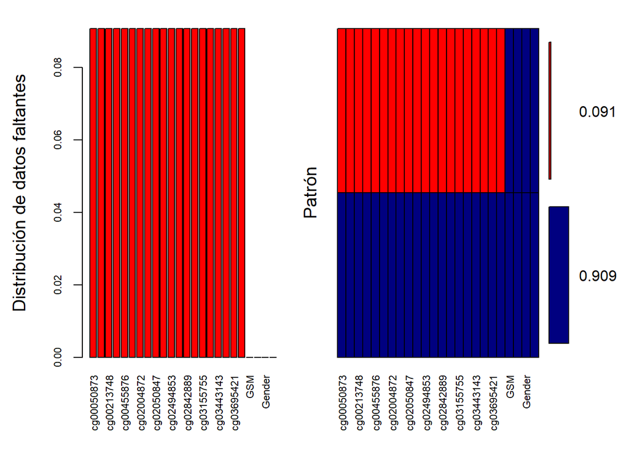

```
##
##  Variables sorted by number of missings:
##        Variable      Count
##      cg00050873 0.09077599
##      cg00212031 0.09077599
##      cg00213748 0.09077599
##      cg00214611 0.09077599
##      cg00455876 0.09077599
##      cg01707559 0.09077599
##      cg02004872 0.09077599
##      cg02011394 0.09077599
##      cg02050847 0.09077599
##      cg02233190 0.09077599
##      cg02494853 0.09077599
##      cg02839557 0.09077599
##      cg02842889 0.09077599
##      cg03052502 0.09077599
##      cg03155755 0.09077599
##      cg03244189 0.09077599
##      cg03443143 0.09077599
##      cg03683899 0.09077599
##      cg03695421 0.09077599
##      cg03706273 0.09077599
##             GSM 0.00000000
##  Smoking Status 0.00000000
##          Gender 0.00000000
##             Age 0.00000000
```

```r
library(VIM)
aggr(datos, col = c("navyblue", "red"), numbers = TRUE, sortVars = TRUE,
     labels = names(datos), cex.axis = .7, gap = 3,
     ylab = c("Distribución de datos faltantes", "Patrón"))
```

Se observa que los datos NA se encuentra en todos los valores, procedamos con la eliminación de los valores nulos, utilizando la función `na.omit()` y el operador pipe `%>%`

```r
library(dplyr) #Libreria a usar
datos <- datos %>% na.omit()
```

Veamos ahora un resumen de los datos

```r
summary(datos)
```

```
##      GSM                     Smoking Status       Gender         Age
##  Length:621         Fuma actualmente:428    Femenino :440   Min.   :18.00
##  Class :character   Nunca fumo      :193    Masculino:181   1st Qu.:46.00
##  Mode  :character                                           Median :54.00
##                                                             Mean   :52.59
##                                                             3rd Qu.:61.00
##                                                             Max.   :70.00
##    cg00050873       cg00212031         cg00213748       cg00214611
##  Min.   :0.1186   Min.   :0.006949   Min.   :0.0000   Min.   :0.01247
##  1st Qu.:0.4131   1st Qu.:0.063172   1st Qu.:0.3635   1st Qu.:0.06946
##  Median :0.5052   Median :0.365545   Median :0.4713   Median :0.41575
##  Mean   :0.5600   Mean   :0.309601   Mean   :0.5191   Mean   :0.34106
##  3rd Qu.:0.8144   3rd Qu.:0.459813   3rd Qu.:0.7278   3rd Qu.:0.49745
##  Max.   :0.8989   Max.   :0.709992   Max.   :0.9236   Max.   :0.80606
##    cg00455876        cg01707559        cg02004872         cg02011394
##  Min.   :0.05917   Min.   :0.04333   Min.   :0.002616   Min.   :0.0000
##  1st Qu.:0.29300   1st Qu.:0.11080   1st Qu.:0.042835   1st Qu.:0.4261
##  Median :0.37968   Median :0.23873   Median :0.149332   Median :0.5157
##  Mean   :0.44718   Mean   :0.21435   Mean   :0.155418   Mean   :0.6058
##  3rd Qu.:0.66283   3rd Qu.:0.28061   3rd Qu.:0.242627   3rd Qu.:0.9412
##  Max.   :0.85443   Max.   :0.46999   Max.   :0.473844   Max.   :0.9792
##    cg02050847        cg02233190         cg02494853        cg02839557
##  Min.   :0.05234   Min.   :0.008632   Min.   :0.01162   Min.   :0.00000
##  1st Qu.:0.33963   1st Qu.:0.088375   1st Qu.:0.02865   1st Qu.:0.06384
##  Median :0.42754   Median :0.259817   Median :0.03695   Median :0.35042
##  Mean   :0.54369   Mean   :0.232498   Mean   :0.04077   Mean   :0.30088
##  3rd Qu.:0.95558   3rd Qu.:0.337023   3rd Qu.:0.04677   3rd Qu.:0.45786
##  Max.   :0.98320   Max.   :0.511730   Max.   :0.28947   Max.   :0.82739
##    cg02842889        cg03052502       cg03155755       cg03244189
##  Min.   :0.01346   Min.   :0.0000   Min.   :0.2020   Min.   :0.02972
##  1st Qu.:0.05483   1st Qu.:0.4025   1st Qu.:0.4245   1st Qu.:0.11976
##  Median :0.39757   Median :0.4940   Median :0.4962   Median :0.20397
##  Mean   :0.32362   Mean   :0.5907   Mean   :0.5895   Mean   :0.19552
##  3rd Qu.:0.47385   3rd Qu.:0.9631   3rd Qu.:0.8988   3rd Qu.:0.24921
##  Max.   :0.85625   Max.   :0.9902   Max.   :0.9696   Max.   :0.54074
##    cg03443143        cg03683899        cg03695421       cg03706273
##  Min.   :0.06496   Min.   :0.00788   Min.   :0.0949   Min.   :0.01120
##  1st Qu.:0.40963   1st Qu.:0.06159   1st Qu.:0.2566   1st Qu.:0.03413
##  Median :0.48314   Median :0.34422   Median :0.3208   Median :0.04961
##  Mean   :0.56841   Mean   :0.28442   Mean   :0.3978   Mean   :0.05769
##  3rd Qu.:0.85436   3rd Qu.:0.41866   3rd Qu.:0.5965   3rd Qu.:0.06916
##  Max.   :0.93589   Max.   :0.65925   Max.   :0.8433   Max.   :0.34380
```

De los **683** registros originales que se tenía, al eliminar los valores nulos nos quedamos con **621** registros indicando que se eliminaron **62** registros.

Teniendo ahora 621 observaciones que tienen todas las variables completas para poder ejecutar los objetivos y análisis de estudio.

## Preguntas objetivo

Tomando en cuenta el contexto explicado sobre la genómica de la metilación en los niveles de CpG island y los datos obtenidos, nos planteamos las siguientes preguntas objetivo que iremos desarrollando:

- **¿Existe relación entre los niveles de CpG island?**
- **¿Existe relación entre el sexo y la metilación de algún CpG island?**

# Sección 3. Análisis exploratorio de los datos

## Análisis descriptivo de los datos univariado

Con el objetivo de poder hallar, a primera instancia, las posibles relaciones existentes entre los niveles de metilación de los CpG Islands con respecto a las condiciones de género, es importante realizar el análisis descriptivo de los datos ya que estos nos ayudan a observar patrones y relaciones entre las variables de estudio.

Primeramente realicemos un análisis univariado de las variables, para después realizar un análisis exploratorio multivariado.

```r
library(skimr)
skim(datos)
```

Data summary

| Name | datos |
| --- | --- |
| Number of rows | 621 |
| Number of columns | 24 |
| _______________________ |  |
| Column type frequency: |  |
| character | 1 |
| factor | 2 |
| numeric | 21 |
| ________________________ |  |
| Group variables | None |

**Variable type: character**

| skim_variable | n_missing | complete_rate | min | max | empty | n_unique | whitespace |
| --- | --- | --- | --- | --- | --- | --- | --- |
| GSM | 0 | 1 | 10 | 10 | 0 | 621 | 0 |

**Variable type: factor**

| skim_variable | n_missing | complete_rate | ordered | n_unique | top_counts |
| --- | --- | --- | --- | --- | --- |
| Smoking Status | 0 | 1 | FALSE | 2 | Fum: 428, Nun: 193 |
| Gender | 0 | 1 | FALSE | 2 | Fem: 440, Mas: 181 |

**Variable type: numeric**

| skim_variable | n_missing | complete_rate | mean | sd | p0 | p25 | p50 | p75 | p100 | hist |
| --- | --- | --- | --- | --- | --- | --- | --- | --- | --- | --- |
| Age | 0 | 1 | 52.59 | 11.45 | 18.00 | 46.00 | 54.00 | 61.00 | 70.00 | ▁▂▅▇▇ |
| cg00050873 | 0 | 1 | 0.56 | 0.20 | 0.12 | 0.41 | 0.51 | 0.81 | 0.90 | ▁▅▇▁▆ |
| cg00212031 | 0 | 1 | 0.31 | 0.19 | 0.01 | 0.06 | 0.37 | 0.46 | 0.71 | ▇▂▇▇▂ |
| cg00213748 | 0 | 1 | 0.52 | 0.21 | 0.00 | 0.36 | 0.47 | 0.73 | 0.92 | ▁▅▇▂▅ |
| cg00214611 | 0 | 1 | 0.34 | 0.21 | 0.01 | 0.07 | 0.42 | 0.50 | 0.81 | ▇▂▇▆▁ |
| cg00455876 | 0 | 1 | 0.45 | 0.20 | 0.06 | 0.29 | 0.38 | 0.66 | 0.85 | ▁▇▃▂▅ |
| cg01707559 | 0 | 1 | 0.21 | 0.09 | 0.04 | 0.11 | 0.24 | 0.28 | 0.47 | ▅▂▇▃▁ |
| cg02004872 | 0 | 1 | 0.16 | 0.11 | 0.00 | 0.04 | 0.15 | 0.24 | 0.47 | ▇▇▆▃▁ |
| cg02011394 | 0 | 1 | 0.61 | 0.24 | 0.00 | 0.43 | 0.52 | 0.94 | 0.98 | ▁▂▇▁▅ |
| cg02050847 | 0 | 1 | 0.54 | 0.28 | 0.05 | 0.34 | 0.43 | 0.96 | 0.98 | ▁▇▅▁▆ |
| cg02233190 | 0 | 1 | 0.23 | 0.13 | 0.01 | 0.09 | 0.26 | 0.34 | 0.51 | ▇▃▇▆▂ |
| cg02494853 | 0 | 1 | 0.04 | 0.02 | 0.01 | 0.03 | 0.04 | 0.05 | 0.29 | ▇▁▁▁▁ |
| cg02839557 | 0 | 1 | 0.30 | 0.19 | 0.00 | 0.06 | 0.35 | 0.46 | 0.83 | ▆▃▇▃▁ |
| cg02842889 | 0 | 1 | 0.32 | 0.20 | 0.01 | 0.05 | 0.40 | 0.47 | 0.86 | ▅▂▇▂▁ |
| cg03052502 | 0 | 1 | 0.59 | 0.26 | 0.00 | 0.40 | 0.49 | 0.96 | 0.99 | ▁▃▇▁▆ |
| cg03155755 | 0 | 1 | 0.59 | 0.22 | 0.20 | 0.42 | 0.50 | 0.90 | 0.97 | ▁▇▃▁▅ |
| cg03244189 | 0 | 1 | 0.20 | 0.09 | 0.03 | 0.12 | 0.20 | 0.25 | 0.54 | ▆▇▆▁▁ |
| cg03443143 | 0 | 1 | 0.57 | 0.21 | 0.06 | 0.41 | 0.48 | 0.85 | 0.94 | ▁▅▇▁▆ |
| cg03683899 | 0 | 1 | 0.28 | 0.18 | 0.01 | 0.06 | 0.34 | 0.42 | 0.66 | ▇▂▇▇▁ |
| cg03695421 | 0 | 1 | 0.40 | 0.19 | 0.09 | 0.26 | 0.32 | 0.60 | 0.84 | ▃▇▁▂▂ |
| cg03706273 | 0 | 1 | 0.06 | 0.04 | 0.01 | 0.03 | 0.05 | 0.07 | 0.34 | ▇▂▁▁▁ |

Se observa una distribución en cada valor de los niveles de CpG island, generalmente sin aproximarse a una distribución normal con diferentes niveles, veamos de forma multivariada

## Análisis multivariado

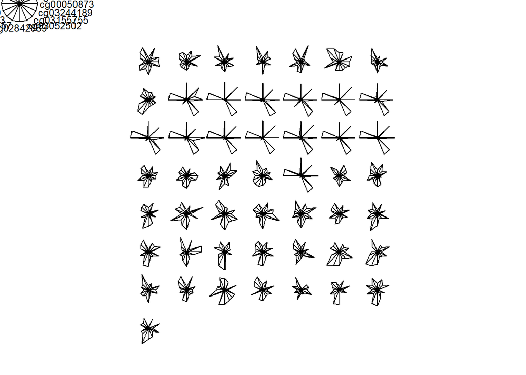

```r
stars(datos[c(1:50),c(5:20)],key.loc=c(-5,20),lwd=1)  # muestra digrama de estrellas
```

Veamos que hay ciertos valores que presentan un patrón similar, en general que pueden ser diferenciados con las técnicas de análisis multivariado.

# Sección 4. Análisis factorial exploratorio

Para este caso se usará el análisis factorial exploratorio para ver si hay relaciones en los niveles de metilación de CpG Island, asimismo para reducir su dimensionalidad y aplicar un modelo de regresión logística, extrayendo las variables numéricas de metilación

```r
metilacion <- datos[,5:24]
```

## Prueba de esfericidad de Bartlet

```r
library(psych)
cortest.bartlett(cor(metilacion), n=nrow(metilacion))
```

```
## $chisq
## [1] 17448.34
##
## $p.value
## [1] 0
##
## $df
## [1] 190
```

Se nos muestra un p valor menor a 0.05, justifica el uso de reducción de datos.

## Indicador Kaiser-Meyer-Olkinn KMO y MSA

```r
KMO(metilacion)
```

```
## Kaiser-Meyer-Olkin factor adequacy
## Call: KMO(r = metilacion)
## Overall MSA =  0.98
## MSA for each item =
## cg00050873 cg00212031 cg00213748 cg00214611 cg00455876 cg01707559 cg02004872
##       0.98       0.99       0.98       0.99       0.99       0.99       0.95
## cg02011394 cg02050847 cg02233190 cg02494853 cg02839557 cg02842889 cg03052502
##       0.98       0.98       0.97       0.57       0.99       0.99       0.99
## cg03155755 cg03244189 cg03443143 cg03683899 cg03695421 cg03706273
##       0.98       0.98       0.99       0.99       0.98       0.80
```

Empezemos realizando la primera seleccionando tomando en cuenta todos los factores

```r
facto=principal(r=metilacion,nfactors=20,rotate="varimax")
facto
```

```
## Principal Components Analysis
## Call: principal(r = metilacion, nfactors = 20, rotate = "varimax")
## Standardized loadings (pattern matrix) based upon correlation matrix
##              RC1   RC3   RC4   RC5   RC2   RC6   RC8   RC7  RC11   RC9  RC12
## cg00050873  0.79 -0.25 -0.12 -0.18 -0.01 -0.13 -0.07  0.06 -0.08 -0.04 -0.05
## cg00212031 -0.61  0.43  0.07  0.20  0.01  0.16  0.58 -0.07  0.08  0.08  0.08
## cg00213748  0.77 -0.22 -0.07 -0.15  0.01 -0.10 -0.08  0.55 -0.08 -0.05 -0.05
## cg00214611 -0.72  0.38  0.08  0.16  0.05  0.15  0.12 -0.07  0.07  0.07  0.50
## cg00455876  0.87 -0.22 -0.09 -0.16 -0.01 -0.11 -0.10  0.06 -0.08 -0.05 -0.04
## cg01707559 -0.59  0.50  0.10  0.23  0.08  0.15  0.12 -0.10  0.51  0.09  0.07
## cg02004872 -0.38  0.88  0.07  0.19  0.07  0.11  0.09 -0.05  0.05  0.04  0.06
## cg02011394  0.81 -0.36 -0.07 -0.14 -0.04 -0.12 -0.11  0.08 -0.07 -0.05 -0.05
## cg02050847  0.88 -0.26 -0.08 -0.19 -0.02 -0.14 -0.12  0.08 -0.09 -0.10 -0.06
## cg02233190 -0.48  0.65  0.08  0.22  0.03  0.18  0.15 -0.10  0.10  0.11  0.07
## cg02494853  0.01  0.06  0.29  0.06  0.95  0.02  0.01  0.00  0.02  0.01  0.01
## cg02839557 -0.58  0.42  0.07  0.18  0.06  0.63  0.13 -0.07  0.09  0.08  0.08
## cg02842889 -0.74  0.41  0.08  0.18  0.03  0.15  0.14 -0.08  0.07  0.07  0.09
## cg03052502  0.84 -0.32 -0.10 -0.17 -0.02 -0.12 -0.09  0.04 -0.06 -0.08 -0.05
## cg03155755  0.81 -0.37 -0.13 -0.17 -0.01 -0.12 -0.11  0.09 -0.08 -0.08 -0.07
## cg03244189 -0.41  0.46  0.12  0.73  0.14  0.12  0.11 -0.07  0.08  0.07  0.06
## cg03443143  0.81 -0.34 -0.10 -0.15 -0.04 -0.15 -0.10  0.03 -0.09 -0.06 -0.06
## cg03683899 -0.64  0.49  0.06  0.20  0.05  0.15  0.12 -0.07  0.10  0.49  0.07
## cg03695421  0.90 -0.26 -0.08 -0.11 -0.01 -0.11 -0.12  0.03 -0.07 -0.06 -0.06
## cg03706273 -0.14  0.08  0.92  0.07  0.34  0.03  0.03 -0.02  0.02  0.01  0.02
##             RC10  RC13  RC14  RC19  RC17  RC15  RC16  RC20  RC18 h2       u2
## cg00050873  0.48 -0.05 -0.04  0.02  0.03  0.00  0.02  0.02  0.00  1  2.2e-16
## cg00212031 -0.05  0.06  0.05 -0.03 -0.03 -0.02 -0.02 -0.02  0.00  1 -7.5e-15
## cg00213748  0.04 -0.05 -0.04  0.01  0.03  0.02  0.01  0.02  0.00  1 -8.9e-16
## cg00214611 -0.05  0.05  0.05 -0.03 -0.02 -0.01 -0.02 -0.02  0.00  1 -3.1e-15
## cg00455876  0.01 -0.04 -0.03  0.00  0.00  0.33 -0.01  0.00  0.00  1 -2.4e-15
## cg01707559 -0.07  0.06  0.04 -0.04 -0.03 -0.03 -0.02 -0.02  0.00  1 -1.8e-15
## cg02004872 -0.04 -0.04  0.04 -0.02 -0.03 -0.01 -0.02 -0.02  0.00  1 -1.1e-15
## cg02011394  0.05 -0.03 -0.02  0.03  0.37  0.00  0.01  0.01  0.00  1 -2.4e-15
## cg02050847  0.01 -0.07 -0.02  0.01 -0.02 -0.05 -0.03 -0.03  0.22  1 -3.1e-15
## cg02233190 -0.08  0.42  0.04 -0.05 -0.02 -0.02 -0.04 -0.02 -0.01  1 -1.8e-15
## cg02494853  0.00  0.00  0.00  0.00  0.00  0.00  0.00  0.00  0.00  1 -2.2e-16
## cg02839557 -0.06  0.06  0.05 -0.04 -0.03 -0.02 -0.02 -0.02  0.00  1 -1.6e-15
## cg02842889 -0.07  0.04  0.41 -0.03 -0.02 -0.02 -0.02 -0.01  0.00  1 -2.4e-15
## cg03052502  0.04 -0.07 -0.03  0.00  0.02 -0.01  0.34  0.01  0.00  1 -2.9e-15
## cg03155755  0.06 -0.04 -0.03  0.02  0.01  0.00  0.01  0.32  0.00  1 -2.4e-15
```

[output cut: 32 more lines]

```
## Cumulative Proportion 0.47 0.63 0.69 0.74 0.80 0.83 0.86 0.88 0.90 0.91 0.93
##                       RC10 RC13 RC14 RC19 RC17 RC15 RC16 RC20 RC18
## SS loadings           0.27 0.23 0.19 0.16 0.15 0.13 0.13 0.11 0.08
## Proportion Var        0.01 0.01 0.01 0.01 0.01 0.01 0.01 0.01 0.00
## Cumulative Var        0.94 0.95 0.96 0.97 0.98 0.98 0.99 1.00 1.00
## Proportion Explained  0.01 0.01 0.01 0.01 0.01 0.01 0.01 0.01 0.00
## Cumulative Proportion 0.94 0.95 0.96 0.97 0.98 0.98 0.99 1.00 1.00
##
## Mean item complexity =  2.4
## Test of the hypothesis that 20 components are sufficient.
##
## The root mean square of the residuals (RMSR) is  0
##  with the empirical chi square  0  with prob <  NA
##
## Fit based upon off diagonal values = 1
```

```r
facto$loadings
```

```
##
## Loadings:
##            RC1    RC3    RC4    RC5    RC2    RC6    RC8    RC7    RC11
## cg00050873  0.790 -0.246 -0.122 -0.178        -0.131
## cg00212031 -0.607  0.434         0.205         0.155  0.578
## cg00213748  0.770 -0.216        -0.147                       0.545
## cg00214611 -0.716  0.384         0.158         0.147  0.122
## cg00455876  0.874 -0.222        -0.164        -0.114
## cg01707559 -0.590  0.503         0.226         0.153  0.117 -0.102  0.507
## cg02004872 -0.384  0.877         0.193         0.109
## cg02011394  0.814 -0.358        -0.137        -0.122 -0.107
## cg02050847  0.877 -0.262        -0.191        -0.138 -0.116
## cg02233190 -0.485  0.654         0.220         0.180  0.149
## cg02494853                0.293         0.952
## cg02839557 -0.581  0.419         0.176         0.626  0.125
## cg02842889 -0.740  0.414         0.178         0.145  0.138
## cg03052502  0.836 -0.317        -0.174        -0.119
## cg03155755  0.813 -0.371 -0.126 -0.172        -0.122 -0.106
## cg03244189 -0.405  0.458  0.125  0.731  0.139  0.119  0.110
## cg03443143  0.806 -0.343 -0.104 -0.150        -0.150
## cg03683899 -0.640  0.487         0.200         0.153  0.124
## cg03695421  0.904 -0.261        -0.111        -0.115 -0.116
## cg03706273 -0.145         0.922         0.338
##            RC9    RC12   RC10   RC13   RC14   RC19   RC17   RC15   RC16
## cg00050873                0.476
## cg00212031
## cg00213748
## cg00214611         0.495
## cg00455876                                                   0.334
## cg01707559
## cg02004872
## cg02011394                                            0.372
## cg02050847 -0.100
## cg02233190  0.107                0.424
## cg02494853
## cg02839557
## cg02842889                              0.410
## cg03052502                                                          0.342
## cg03155755
## cg03244189
```

[output cut: 19 more lines]

```
## cg03155755  0.316
## cg03244189
## cg03443143
## cg03683899
## cg03695421        -0.175
## cg03706273
##
##                  RC1   RC3   RC4   RC5   RC2   RC6   RC8   RC7  RC11   RC9
## SS loadings    9.330 3.365 1.083 1.078 1.066 0.704 0.543 0.383 0.367 0.325
## Proportion Var 0.467 0.168 0.054 0.054 0.053 0.035 0.027 0.019 0.018 0.016
## Cumulative Var 0.467 0.635 0.689 0.743 0.796 0.831 0.858 0.878 0.896 0.912
##                 RC12  RC10  RC13  RC14  RC19  RC17  RC15  RC16  RC20  RC18
## SS loadings    0.317 0.267 0.230 0.193 0.157 0.150 0.130 0.128 0.109 0.078
## Proportion Var 0.016 0.013 0.012 0.010 0.008 0.007 0.006 0.006 0.005 0.004
## Cumulative Var 0.928 0.941 0.953 0.962 0.970 0.978 0.984 0.991 0.996 1.000
```

Por la mayor explicación de la varianza, se recomienda usar 3 o 4 factores, utilizemos 3 factores

```r
facto=principal(r=metilacion,nfactors=3,rotate="varimax")
facto
```

```
## Principal Components Analysis
## Call: principal(r = metilacion, nfactors = 3, rotate = "varimax")
## Standardized loadings (pattern matrix) based upon correlation matrix
##              RC1   RC3   RC2   h2    u2 com
## cg00050873  0.83 -0.36 -0.10 0.83 0.170 1.4
## cg00212031 -0.64  0.63  0.05 0.81 0.191 2.0
## cg00213748  0.84 -0.31 -0.05 0.80 0.198 1.3
## cg00214611 -0.74  0.52  0.09 0.83 0.172 1.8
## cg00455876  0.88 -0.33 -0.07 0.89 0.115 1.3
## cg01707559 -0.61  0.68  0.13 0.84 0.156 2.1
## cg02004872 -0.36  0.87  0.09 0.88 0.117 1.4
## cg02011394  0.82 -0.45 -0.07 0.88 0.125 1.6
## cg02050847  0.87 -0.40 -0.07 0.93 0.073 1.4
## cg02233190 -0.49  0.80  0.06 0.88 0.118 1.7
## cg02494853  0.07  0.13  0.90 0.82 0.176 1.1
## cg02839557 -0.62  0.63  0.09 0.78 0.217 2.0
## cg02842889 -0.76  0.54  0.08 0.87 0.127 1.8
## cg03052502  0.84 -0.43 -0.08 0.89 0.114 1.5
## cg03155755  0.82 -0.47 -0.09 0.91 0.091 1.6
## cg03244189 -0.40  0.75  0.22 0.78 0.220 1.7
## cg03443143  0.81 -0.46 -0.10 0.87 0.128 1.6
## cg03683899 -0.65  0.65  0.07 0.85 0.151 2.0
## cg03695421  0.88 -0.34 -0.05 0.90 0.096 1.3
## cg03706273 -0.21  0.06  0.88 0.82 0.185 1.1
##
##                        RC1  RC3  RC2
## SS loadings           9.70 5.63 1.73
## Proportion Var        0.48 0.28 0.09
## Cumulative Var        0.48 0.77 0.85
## Proportion Explained  0.57 0.33 0.10
## Cumulative Proportion 0.57 0.90 1.00
##
## Mean item complexity =  1.6
## Test of the hypothesis that 3 components are sufficient.
##
## The root mean square of the residuals (RMSR) is  0.02
##  with the empirical chi square  91.32  with prob <  1
##
## Fit based upon off diagonal values = 1
```

```r
facto$loadings
```

```
##
## Loadings:
##            RC1    RC3    RC2
## cg00050873  0.832 -0.358 -0.101
## cg00212031 -0.640  0.630
## cg00213748  0.838 -0.314
## cg00214611 -0.743  0.517
## cg00455876  0.878 -0.330
## cg01707559 -0.609  0.675  0.132
## cg02004872 -0.355  0.865
## cg02011394  0.818 -0.449
## cg02050847  0.874 -0.399
## cg02233190 -0.493  0.797
## cg02494853         0.129  0.896
## cg02839557 -0.620  0.625
## cg02842889 -0.758  0.540
## cg03052502  0.835 -0.426
## cg03155755  0.823 -0.471
## cg03244189 -0.399  0.755  0.224
## cg03443143  0.809 -0.456 -0.102
## cg03683899 -0.647  0.652
## cg03695421  0.885 -0.344
## cg03706273 -0.213         0.875
##
##                  RC1   RC3   RC2
## SS loadings    9.699 5.630 1.732
## Proportion Var 0.485 0.282 0.087
## Cumulative Var 0.485 0.766 0.853
```

Para este caso no se interpretará los componentes, para el objetivo solo se extraerá los factores loadings, se estandarizará y posteriormente se aplicará la regresión logística para la clasificación del género.

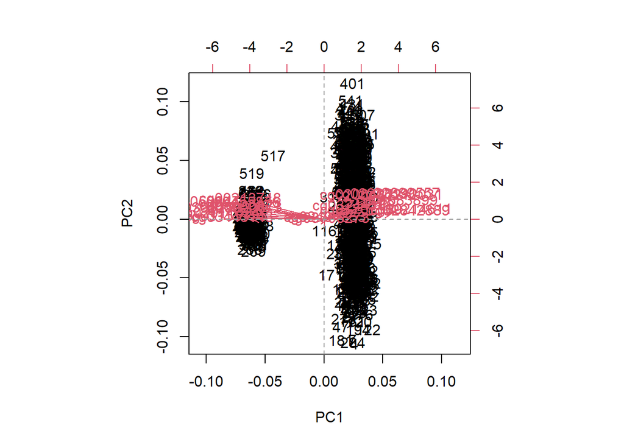

```r
biplot(prcomp(metilacion, scale = FALSE))
abline(h = 0, v = 0, lty = 2, col = 8)
```

Como se observa hay mejor distinción de las variables con respecto a sus factores.

## Extracción y transformación de los factores

Saquemos ahora los scores

```r
scores <- as.matrix(metilacion) %*% as.matrix(facto$loadings)
scores <- data.frame(scores) ; head(scores)
```

```
##         RC1       RC3        RC2
## 1 1.1655648 0.4108950 0.15523468
## 2 1.3382358 0.2369817 0.08807433
## 3 1.2151356 0.2853904 0.04043078
## 4 1.1186002 0.2108934 0.08546824
## 5 0.8454848 0.5407476 0.12093196
## 6 1.5537292 0.4337836 0.01431696
```

Realizemos una transformación manteniendo sus características, para este caso en lugar de realizar la tranformacion por la estandarización normal, se aplicará mínimos y máximos para que tenga interpretabilidad con los porcentajes de metilación de CpG Island

```r
library(scales)
scores$RC1 <- rescale(scores$RC1, to = c(0,1))
scores$RC3 <- rescale(scores$RC3, to = c(0,1))
scores$RC2 <- rescale(scores$RC2, to = c(0,1))
```

**Interpretación:** Se observa que con los 3 factores se puede explicar el 85.3% de la variabilidad. Esto indica que la variable a estudiar puede ser fácilmente explicada a través de tres factores de tal forma que se reduzca la dimensionalidad de 20 niveles de metilación a CpG a solo tres factores que puedan explicar el 85.3% de la variabilidad de estos niveles.

# Sección 5. Regresión logística

Empezemos realizando la unión de los datos originales con los tres factores para aplicar una regresión logística y ver si se realizar una clasificación de los niveles de metilación de CpG Island con respecto al género.

```r
data_AFE <- cbind(datos,scores)
data_AFE <- data_AFE %>% select(Gender, RC1, RC2, RC3)
head(data_AFE)
```

```
##     Gender        RC1       RC2       RC3
## 1 Femenino 0.13810658 0.6625407 0.7951542
## 2 Femenino 0.16575880 0.5990949 0.7543568
## 3 Femenino 0.14604504 0.5540864 0.7657127
## 4 Femenino 0.13058547 0.5966329 0.7482368
## 5 Femenino 0.08684769 0.6301352 0.8256156
## 6 Femenino 0.20026876 0.5294168 0.8005235
```

Previamente veamos en un gráfico de cajas los diferentes factores y la clasificación del género

## Visualización de los factores y el género

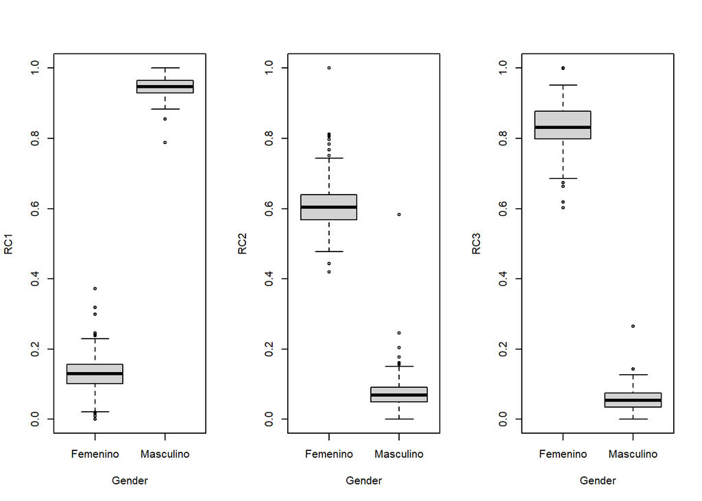

```r
par(mfrow = c(1,3))
boxplot(RC1 ~ Gender, data = data_AFE)
boxplot(RC2 ~ Gender, data = data_AFE)
boxplot(RC3 ~ Gender, data = data_AFE)
```

Se observan diferencias entre ambos grupos con respecto a los niveles de metilación de CpG Island

```r
par(mfrow = c(1,1))
```

## Aplicación del modelo logístico

Veamos el modelo logístico

```r
modelo_logistic <- glm(Gender ~ ., family=binomial,data=data_AFE)
summary(modelo_logistic)
```

```
##
## Call:
## glm(formula = Gender ~ ., family = binomial, data = data_AFE)
##
## Coefficients:
##              Estimate Std. Error z value Pr(>|z|)
## (Intercept)   -153.63  309137.92   0.000        1
## RC1            186.77  306490.57   0.001        1
## RC2             15.05  322289.65   0.000        1
## RC3             96.44  369229.58   0.000        1
##
## (Dispersion parameter for binomial family taken to be 1)
##
##     Null deviance: 7.4950e+02  on 620  degrees of freedom
## Residual deviance: 8.5151e-09  on 617  degrees of freedom
## AIC: 8
##
## Number of Fisher Scoring iterations: 25
```

En este caso hay un notorio sobreajuste de los datos, ya que como se observa la diferenciación entre grupos es muy evidente. veamos con la ayuda de stepAIC

```r
library(MASS)
modelo_logistic <- stepAIC(modelo_logistic)
```

```
## Start:  AIC=8
## Gender ~ RC1 + RC2 + RC3
```

```
##        Df   Deviance AIC
## - RC2   1 8.6062e-09   6
## - RC3   1 1.0514e-08   6
## - RC1   1 1.2663e-08   6
## <none>    8.5151e-09   8
```

```
##
## Step:  AIC=6
## Gender ~ RC1 + RC3
```

```
##        Df   Deviance AIC
## - RC3   1 1.0676e-08   4
## - RC1   1 1.3052e-08   4
## <none>    8.6062e-09   6
```

```
##
## Step:  AIC=4
## Gender ~ RC1
##
##        Df Deviance   AIC
## <none>         0.0   4.0
## - RC1   1    749.5 751.5
```

```r
summary(modelo_logistic)
```

```
##
## Call:
## glm(formula = Gender ~ RC1, family = binomial, data = data_AFE)
##
## Coefficients:
##             Estimate Std. Error z value Pr(>|z|)
## (Intercept)   -54.86   23343.01  -0.002    0.998
## RC1            95.01   40739.62   0.002    0.998
##
## (Dispersion parameter for binomial family taken to be 1)
##
##     Null deviance: 7.4950e+02  on 620  degrees of freedom
## Residual deviance: 1.0676e-08  on 619  degrees of freedom
## AIC: 4
##
## Number of Fisher Scoring iterations: 25
```

Con el modelo saquemos los errores de clasificación

```r
yprob<-predict(modelo_logistic,type="response")
head(yprob)
```

```
##            1            2            3            4            5            6
## 2.220446e-16 2.220446e-16 2.220446e-16 2.220446e-16 2.220446e-16 2.220446e-16
```

## Matriz de confusión

```r
ypred <- as.numeric(yprob >= 0.5 )
ypred <- factor(ypred, labels = levels(data_AFE$Gender))

# Matriz de Confusión
(mc<-table(ypred,data_AFE$Gender))
```

```
##
## ypred       Femenino Masculino
##   Femenino       440         0
##   Masculino        0       181
```